# `MADloy`: Detecting mosaic loss of Y events on SNP and NGS data

Marcos Lopez-Sanchez, Juan R. Gonzalez

Institute for Global Health (ISGlobal), Barcelona, Spain Bioinformatics Research Group in Epidemiolgy (BRGE) (http://www.creal.cat/brge.htm)

25 enero 2017

#### Package version: MADloy 0.9.5.25

# 1 Introduction

`MADloy` is a package to detect mosaic loss of chromosome Y (LOY) events from NGS and SNP data. It uses a bivariate mixture model which uses values in a target region of chromosome Y and in two reference chromosomes across several samples in order to detect those samples with altered values (LOY or GAIN) from the main population. The measures compared are different depending the type of data analyzed. Depth coverage is used for NGS data (exome sequencing data) and log R ratio (LRR) for SNP array data.

By default, the region used to detect LOY is a region in chromosome Y region that avoids the PAR1 and PAR2 regions shared with chromosome X (mY). In order to take into consideration the variability of coverage or LRR in a given sample, the method clusters individuals into LOY, normal and GAIN categories by using a bivariate vector having data at mLRR-Y region and whole chromosome 22. Nonetheless, the reference region can be set manually. The package summarizes the coverage (median, mean and trimmed-mean) in all sequenced positions for the analyzed region when having NGS data, and the median LRR in the probes contained in the SNP array. These bivariate observations are computed for each individual and a bivariate mixture model is fitted in order to: 1st) decide how many cluster are in the data (2: LOY and Normal or 3: LOY, Normal and GAIN) and 2nd) call individuals.

You can install `MADloy` from Github by typing

```r
devtools::install_github("isglobal-brge/MADloy")
```

```r
library(MADloy)
```

# 2 Processing data (load and summarize)

`MADloy` contains a different function to pre-process your data depending on the technology. `madloy` processes SNP array data, while `madseqloy` deals with Exome Sequencing data. Next, we illustrate how to preform this step in both situations.

## 2.1 Processing SNP data with `madloy`

Detecting LOY events in SNP arrays requires to get summarized data from log R ratio (LRR) files. The idea is to see whether LRR in the male-specific region of chromosome Y (mLRR-Y) is different from 0. The mLRR-Y corresponds to the 56-Mb region between pseudoautosomal regions 1 and 2 (PAR1 and PAR2) on chromosome Y (chrY:2,694,521-59,034,049, hg19/GRCh37).

If your data has been obtained from Illumina arrays, LRR can be obtained from the reports generated with BeadStudio tool (see for instance `MAD` package documentation [here](http://www.creal.cat/media/upload/arxius/jr/GADA/mad_vignette.pdf)), or other R packages as [`crlmm`](http://bioconductor.org/packages/release/bioc/html/crlmm.html) or [`beadarraySNP`](https://www.bioconductor.org/packages/release/bioc/html/beadarraySNP.html). If your data has been generated from any Affymetrix chip (e.g. GenomeWide, Axiom or CytoScan) you can use the either Affymetrix Power Tools (APT) or `affy2sv` package [`affy2sv`](http://bioconductor.org/packages/release/bioc/html/affy2sv.html). The function to process LRR files only requires the path indicanting were those files are located. Let us illustrate how to get summarized data from 3 samples having information about LRR that are available at `MADloy` package. The folder can be get by writting:

```r
rawDataPath <- system.file("extdata", "rawData", package = "MADloy")
rawDataPath
```

```
## [1] "C:/Users/jrgonzalez/Documents/R/win-library/3.3/MADloy/extdata/rawData"
```

```r
dir(rawDataPath)
```

```
## [1] "Sample1.txt" "Sample2.txt" "Sample3.txt"
```

Then, data can be summarized by usgin `madloy` function. The function creates an object of class `MADloy` that can be inspected by using the generic `print` function.

```r
res <- madloy(rawDataPath)
```

[output not shown]

```
## Reference region 1 set to chr21 by default
```

```
## Reference region 2 set to chr22 by default
```

```
## LRR median will be computed in reference regions chr21, chr22 and target region chrY:7000000-30000000
```

```
## Processing 3 file(s)...
```

```r
res
```

```
## Object of class MADloy
## ----------------------------
## Number of processed samples: 3
## Target region: chrY:7000000-30000000
## Reference region 1: chr21:1-300000000
## Reference region 2: chr22:1-300000000
```

We can manually inspect information of mLRR-Y region (e.g., one by one sample) and decide whether a given individulas is having a LOY or not. For example this code will create the plot of Sample1 where LRR in the mLRR-Y region (shaded area) is clearly lost.

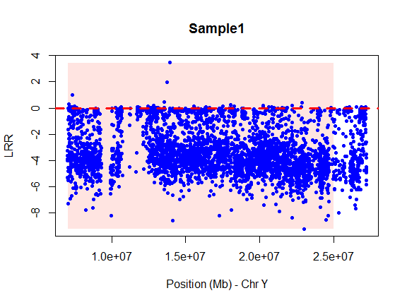

LRR in the mLRR.Y region (shaded) of Sample1 from the illustrative example

```r
plotIndSNP(res, sample="Sample1")
```

The same figure can be obtained of Sample2 which is not having a LOY event:

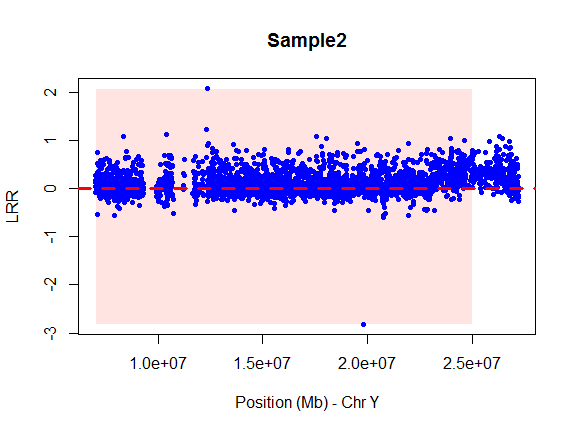

LRR in the mLRR.Y region (shaded) of Sample2 from the illustrative example

```r
plotIndSNP(res, sample="Sample2")
```

However, when thousands of samples are analyzed a proper statistical method can be used to differenciate those samples that are having LOY. Next section illustrate how to visualize the information of mLRR-Y of lot of samples

### 2.1.1 Visualizing a set of SNP samples

Let us illustrate how to visualize the data using 89 CEU HapMap samples. Already pre-processed data can be retrieved into your `R` session from the `MADloyHapMapAll` data set that is included in the package by simply typing:

```r
data(MADloy_HapMapAll)
MADloyHapMapAll
```

```
## Object of class MADloy
## ----------------------------
## Number of processed samples: 89
## Target region: chrY:7000000-30000000
## Reference region 1: chr21:1-300000000
## Reference region 2: chr22:1-300000000
```

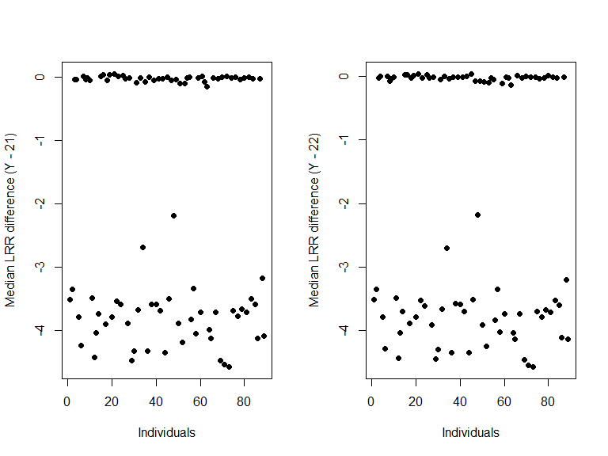

Plot of MADloy object including 89 HapMap samples

```r
plot(MADloyHapMapAll)
```

This figure shows several samples having LOY (those in the -2, -4 range of Y-axis) that correspond to female samples. Of course, these are not real LOY samples since females are expected to show this pattern. Let us pay attention in the male individuals that are also available as a data example in our package. We have selected 23 male samples whose pre-processed LLR that can be get into `R`by:

```r
data(MADloy_HapMapMale)
MADloyHapMapMale
```

```
## Object of class MADloy
## ----------------------------
## Number of processed samples: 23
## Target region: chrY:7000000-30000000
## Reference region 1: chr21:1-300000000
## Reference region 2: chr22:1-300000000
```

The plot is obtained by

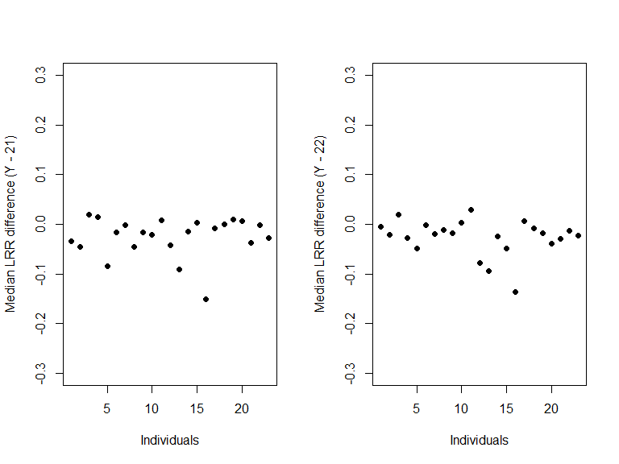

```r
plot(MADloyHapMapMale, ylim=c(-0.3, 0.3))
```

We observe that there are some points that deviate from 0. The question is to determine whether those samples belong to the general population of normal samples.

## 2.2 Processing NGS Exome-seq data with `madseqloy`

To detect samples having LOY events when using NGS data requires a very similar procedure as the one used for SNP data. In that case the required input files are indexed .bam files. The next code illustrate how to download and analyze two Hapmap samples sequenced in the 1000 Genomes project. This code is not executed due to the large size of Exome-seq data files. However, if you want to reproduce the results, you can try it. It is required that .bam files are indexed. Therefore, the .bai index files must also be in the same folder. It is required that both files (.bam and .bai) have the same filename (i.e. test.bam and test.bai). If you don’t have an index file, you can create it by using the function `indexBam` from `Rsamtools` package if the .bam file is sorted. Otherwise, you will need to sort it beforehand with the function `sortBam` also from `Rsamtools`.

```r
download.file(url = "ftp://ftp.1000genomes.ebi.ac.uk/vol1/ftp/phase3/data/HG12716/exome_alignment/HG00236.mapped.ILLUMINA.bwa.GBR.exome.20121211.bam",
              destfile = "/tmp/HG00236.mapped.ILLUMINA.bwa.GBR.exome.20121211.bam.bai")
download.file(url = "ftp://ftp.1000genomes.ebi.ac.uk/vol1/ftp/phase3/data/HG00236/exome_alignment/HG00236.mapped.ILLUMINA.bwa.GBR.exome.20121211.bam.bai",
              destfile = "/tmp/HG00236.mapped.ILLUMINA.bwa.GBR.exome.20121211.bam.bai")
```

As in the case of using `madloy` function, the folder having the .bam and .bai files must be provided. As previously mentioned, exome sequencing data also requires the targets file. The function `madseqloy` recursively processes all .bam files that are provided in the path. An object of class `MADseqLOY` is created.

```r
res2 <- madseqloy(files = "/tmp", exomeTargets = "/tmp/S0293689/S0293689_Padded.bed")
```

The samples analyzed can be visualized one by one from the `MADseqLOY` object using the function `plotIndNGS` which is similar to the one designed for SNP array data. However, it is highly recommended to have a minimum of 4GB of RAM memory to draw the plot. Otherwise, it could crash or take long time in finishing. The plot for a given sample can be created using `plotIndNGS`function. It requires an object of class `MADseqLOY` and the name of the sample. The `MADseqLOY` object stores the files in a vector that can be access through in res2$par$files where ‘res2’ is the name of the `MADseqLOY` object. The name of the file can also be passed to this argument.

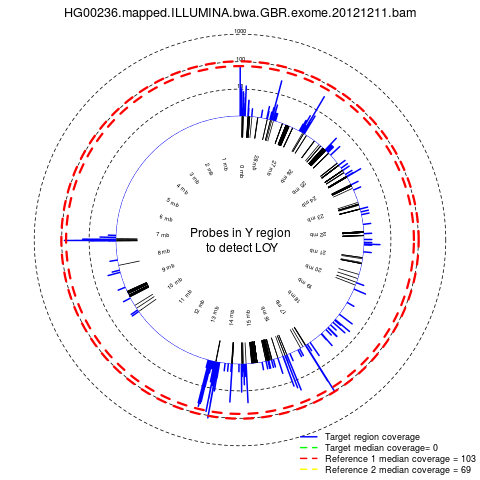

Plot of a female HapMap sample in a MADseqLOY object

```r
plotIndNGS(res2, sample = res$par$files[1])
```

### 2.2.1 Visualizing a set of NGS samples

```r
load("../../MADseqLOY_BLCA.rda")
BLCA
```

```
##
## Object of class MADseqLOY
## ----------------------------
## Number of processed samples: 26
## Target region: chrchrY:7000000-30000000
## Reference region 1: chrchr21:1-300000000
## Reference region 2: chrchr22:1-300000000
```

Summarized coverage in mY region of each sample can be plotted by using the generic function `plot`:

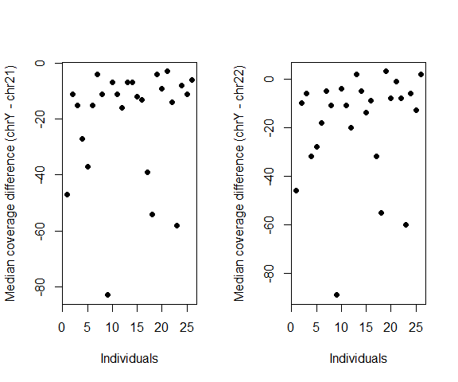

```r
plot(BLCA)
```

Let us verify whether the subject having the lowest coverage is a having a LOY. The id of that sample can be retrived by executing:

```r
dd <- MADloy:::getMedian(BLCA)
id.tcga.low <- substr(rownames(dd)[which.min(dd[,1])], 6, 21)
id.tcga.low
```

```
## [1] "TCGA-GD-A3OP-10A"
```

LRR can be downloaded from TCGA since this information is considered of level 3 and it is available from TCGA Data Portal. The plot of mY region of that sample can be obtained by simply typing (NOTE: The function `plotIndSNP` can procude this plot from: 1) an object of class `madloy`; 2) a matrix having chromosome, position and LRR; or 3) a path indicanting where a file having chromosome, position and LRR is located).

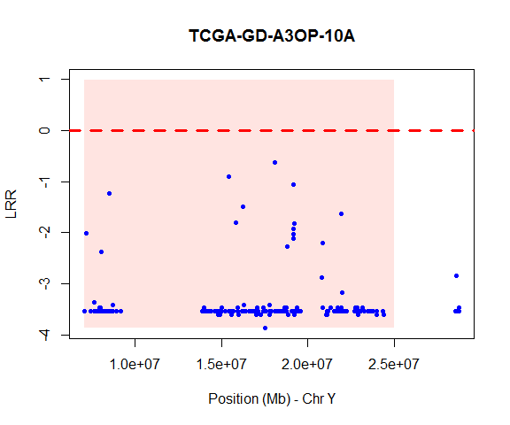

```r
folder <- "../../BLCAdata/rawData"
plotIndSNP(file.path(folder, paste0(id.tcga.low, ".txt")))
```

# 3 Detecting LOY events

Once samples have been processed, the user will have either a `MADloy` or `MADseqLOY` object. The next step is to detect those samples having a LOY event. The calling is performed equally in both cases by using the function `getLOY`. This function uses the Hermite distribution when analyzing LRR (e.g SNP data) and implements a mixture of binormal data in the case of having coverage (e.g NGS data). The main manuscript describes how these methods are implemented to detect LOY events in both type of data.

Let us start by illustrating how to detect LOY in the HapMap samples. The object containing preprocessed data is called `MADloyHapMapMale`. Calling is performed by typing:

```r
nsamples <- length(MADloyHapMapMale$par$files)
ans <- getLOY(MADloyHapMapMale, pval.harm = 0.05/nsamples)
```

Results can be visualized with the generic `plot` function as follows:

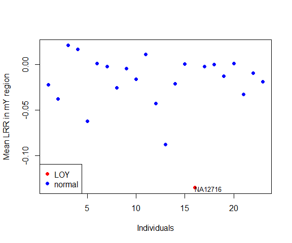

Plot of a LOY object obtained from SNP array data

```r
plot(ans)
```

```r
PathHapMapLRR <- system.file("extdata", package = "MADloy")
list.files(PathHapMapLRR, pattern=".txt")
```

```
## [1] "NA07048.txt" "NA11829.txt" "NA12144.txt" "NA12716.txt"
```

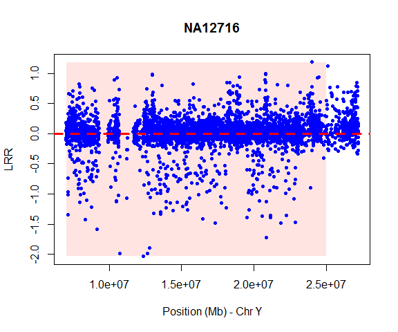

```r
plotIndSNP(file.path(PathHapMapLRR, "NA12716.txt"))
```

```r
ans2 <- getLOY(BLCA)
```

And the figure to determine LOY samples can be obtained by:

```r
plot(ans2)
```

[output not shown]